# Untitled

2022-08-14

## Essential Packages

```r
library("caret")
library("randomForest")
library("rpart")
library("gbm")
library("survival")
library ("splines")
```

# Data Processing

## Reading Data

#### 1. Training and Testing Data is read from online source.

```r
## Download and read raw data
url1 <- "http://d396qusza40orc.cloudfront.net/predmachlearn/pml-training.csv"
download.file(url1, destfile="pml-training.csv")
url2 <- "http://d396qusza40orc.cloudfront.net/predmachlearn/pml-testing.csv"
download.file(url2, destfile="pml-testing.csv")
dataTrain <- read.csv("pml-training.csv", header=TRUE)
dataTest <- read.csv("pml-testing.csv", header=TRUE)
```

#### 2. The dataTest set is held out. Exploration and subsequent analysis are only performed on the dataTrain set.

#### 3. After performing the command str(dataTrain), it is determined that there are 19622 observations, consisting of 160 variables.

## Normalizing and Selecting Data

#### 1. It is noted that many variables in the dataset contain invalid values such as NA’s and blanks. For example the dataTrain$var_total_accel_belt variable below. It is decided that such variables with large amount of invalid values be excluded from the model.

```r
summary(dataTrain$var_total_accel_belt)
```

```
##    Min. 1st Qu.  Median    Mean 3rd Qu.    Max.    NA's
##   0.000   0.100   0.200   0.926   0.300  16.500   19216
```

#### 2. After excluding the abovementioned variables, it is found that the data has no more invalid values as described by complete.cases command. We now have 54 variables, including the variable to be predicted, classe.

```r
dataTidy <- dataTrain[,-c(grep("^amplitude|^kurtosis|^skewness|^avg|^cvtd_timestamp|^max|^min|^new_window|^raw_timestamp|^stddev|^var|^user_name|X",names(dataTrain)))]

paste("Complete Cases:")
```

```
## [1] "Complete Cases:"
```

```r
table(complete.cases(dataTidy))
```

```
##
##  TRUE
## 19622
```

## Data Splitting

#### 1. Given that we have a medium to large sample size, it is decided that the tidy data be further split into two sets, 60% for training and 40% for testing.

```r
set.seed(39)
inTrain <- createDataPartition(y=dataTidy$classe,
                               p=0.6,list=FALSE)
dataTidyTrain <- dataTidy[inTrain,]
dataTidyTest <- dataTidy[-inTrain,]
```

# Model Selection

## Model Comparison

#### 1. It is determined that this is a classification problem and the aim of the comparison is to discover which algorithm suits the data better.

#### 2.The RandomForest rf and Gradient Boosting gbm algorithms are selected for comparison based on the accuracy these algorithms can achieve in classification. (Refer to lectures) In addition, these 2 models have built-in feature selection as described in the Caret package reference. (Refer to [1])

#### 3. The Kappa metric is selected as the comparison criteria.

#### 4. To reduce the risk of overfitting, a 10-fold cross validation is employed during model building. (Refer to lectures and [2])

```r
set.seed(39)
# k-fold validation - 10-fold validation, use kappa as metric
fitControl <- trainControl(method = "cv",
                           number = 10)
gbmFit <- train(classe~., data=dataTidyTrain, method="gbm", metric="Kappa", trControl=fitControl,verbose=FALSE)
```

```r
rfFit <- train(classe~.,data=dataTidyTrain,method="rf", metric="Kappa", trControl=fitControl)
```

## Model Selection

```r
library(lattice)
rValues <- resamples(list(rf=rfFit,gbm=gbmFit))
summary(rValues)
```

```
##
## Call:
## summary.resamples(object = rValues)
##
## Models: rf, gbm
## Number of resamples: 10
##
## Accuracy
##          Min.   1st Qu.    Median      Mean   3rd Qu.      Max. NA's
## rf  0.9931973 0.9940577 0.9966022 0.9960080 0.9974528 0.9991518    0
## gbm 0.9770798 0.9823931 0.9847137 0.9848005 0.9885275 0.9898132    0
##
## Kappa
##          Min.   1st Qu.    Median     Mean   3rd Qu.      Max. NA's
## rf  0.9913931 0.9924828 0.9957016 0.994950 0.9967785 0.9989273    0
## gbm 0.9709943 0.9777301 0.9806611 0.980771 0.9854885 0.9871145    0
```

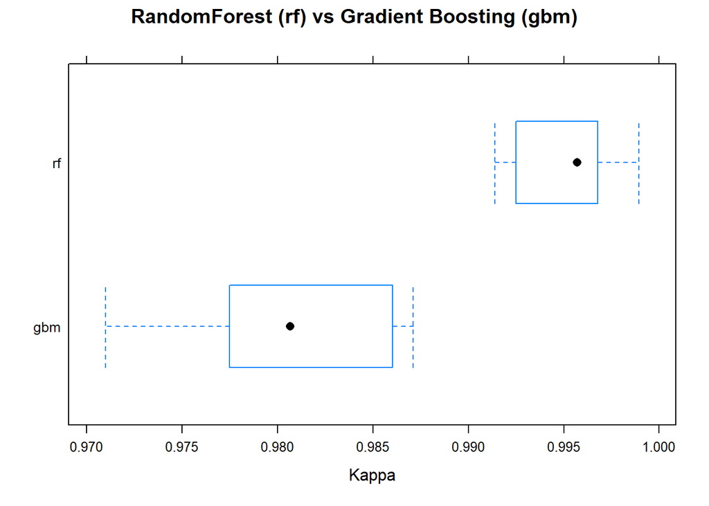

```r
bwplot(rValues,metric="Kappa",main="RandomForest (rf) vs Gradient Boosting (gbm)")
```

# Model Validation

#### 1. With the selected RandomForest model, we shall proceed to model validation.

#### 2. The details of the selected model is shown below.

```r
rfFit
```

```
## Random Forest
##
## 11776 samples
##    53 predictor
##     5 classes: 'A', 'B', 'C', 'D', 'E'
##
## No pre-processing
## Resampling: Cross-Validated (10 fold)
## Summary of sample sizes: 10599, 10597, 10600, 10598, 10598, 10599, ...
## Resampling results across tuning parameters:
##
##   mtry  Accuracy   Kappa
##    2    0.9932910  0.9915124
##   27    0.9960080  0.9949500
##   53    0.9921871  0.9901171
##
## Kappa was used to select the optimal model using the largest value.
## The final value used for the model was mtry = 27.
```

#### 3. We shall be using the confusionMatrix function in the Caret package to validate the selected model with the dataTidyTest test set. The corresponding statistics and error rates are shown.

```r
#factor(dataTidyTest$classe)
confusionMatrix(factor(dataTidyTest$classe), predict(rfFit,dataTidyTest))
```

```
## Confusion Matrix and Statistics
##
##           Reference
## Prediction    A    B    C    D    E
##          A 2232    0    0    0    0
##          B    8 1507    3    0    0
##          C    0    4 1364    0    0
##          D    0    0    4 1282    0
##          E    0    0    0    4 1438
##
## Overall Statistics
##
##                Accuracy : 0.9971
##                  95% CI : (0.9956, 0.9981)
##     No Information Rate : 0.2855
##     P-Value [Acc > NIR] : < 2.2e-16
##
##                   Kappa : 0.9963
##
##  Mcnemar's Test P-Value : NA
##
## Statistics by Class:
##
##                      Class: A Class: B Class: C Class: D Class: E
## Sensitivity            0.9964   0.9974   0.9949   0.9969   1.0000
## Specificity            1.0000   0.9983   0.9994   0.9994   0.9994
## Pos Pred Value         1.0000   0.9928   0.9971   0.9969   0.9972
## Neg Pred Value         0.9986   0.9994   0.9989   0.9994   1.0000
## Prevalence             0.2855   0.1926   0.1747   0.1639   0.1833
## Detection Rate         0.2845   0.1921   0.1738   0.1634   0.1833
## Detection Prevalence   0.2845   0.1935   0.1744   0.1639   0.1838
## Balanced Accuracy      0.9982   0.9978   0.9971   0.9981   0.9997
```

# Final Model Testing

#### Finally, we shall use the selected model to predict the classification of the testing set provided.

```r
results <- predict(rfFit,newdata=dataTest)
print(as.data.frame(results))
```

```
##    results
## 1        B
## 2        A
## 3        B
## 4        A
## 5        A
## 6        E
## 7        D
## 8        B
## 9        A
## 10       A
## 11       B
## 12       C
## 13       B
## 14       A
## 15       E
## 16       E
## 17       A
## 18       B
## 19       B
## 20       B
```